# Temperature-dependence of life history in an edible cricket: Implications for optimising mass rearing

Part 2: Effects of rearing temperature on reproductive output

Author

Affiliation

Jacinta Kong

Department of Biology, Carleton Univeristy, Canada

Published

February 27, 2025

# 1 Aim

This experiment aimed to characterise the effects of rearing temperature on the reproductive output of *Gryllodes sigillatus*, the banded cricket, under common garden conditions. This experiment follows up from Part 1 and uses a subset of temperature treatments from Part 1 that allows for continuous development to adulthood and are relevant for mass-rearing.

# 2 Design

- 5 temperatures: 30, 32, 34, 36, 38 °C
- 40 crickets per temperature reared to adulthood, split across 2 incubators and moved between incubators three times a week
- Crickets that moulted into the adult instar within a week were paired and moved to 32 °C.

# 3 Setup

```r
library(tidyverse)
library(knitr)
opts_chunk$set(message = FALSE, warning = FALSE)
library(broom)
library(emmeans)
library(cowplot) # plotting
library(nlme)

# Set plot themes
ggplot2::theme_set(theme_classic())
ggplot2::theme_update(text = element_text(size = 10),
                      panel.background = element_rect(fill = "transparent"),
                      plot.background = element_rect(fill = "transparent",
                                                     colour = NA),
                      legend.box.background = element_rect(fill = "transparent",
                                                           colour = NA),
                      legend.background = element_rect(fill = "transparent"),
                      strip.background = element_rect(fill = "transparent",
                                                      colour = NA),
                      strip.text = element_text(face = "bold")
                      )
# Colour palettes
sex_pal <- c("gray60", "#E69F00", "#0072B2")  # Sex
temperature_pal <- viridisLite::viridis(end = 0.95, n = 10, option = "plasma")[6:10]
```

## 3.1 Import data

The data are contained in three csv files.

1. F1_ParentID - Life history information about the parents

temperature: Rearing temperature (Vevor incubators)  
ID_P: Unique identifier for the individual  
date_hatched: Date individual hatched  
date_start: Date individual was allocated to rearing temperature  
date_end: Date individual was removed from experiment (Death, Maturity or Completion)  
reason_removed: Reason individual was removed from experiment  
date_subadult: Date individual could be identified to sex  
sex: Sex of individual  
date_adult: Date individual reached adulthood  
container: Mass (g) of the weighing container  
container_adult: Mass (g) of the weighing container and the adult individual  
pair: Unique identifier of the mating pair  
date_paired: Date cricket was allocated mating pair  
excluded: Flag for whether cricket was excluded from analysis  
reason_excluded: Reason for why cricket was excluded from analysis  
notes: Other observations

2. F1_eggs - Number of eggs laid for each pair every 48h.

Rows are individual pairs.  
Columns are data collection dates

3. F1_hatch - Batches of eggs incubated

date_laid: Date batch of eggs was laid  
pair: Unique identifier of the mating pair (parents)  
hatching_success: Flag for whether at least one egg hatched  
date_hatched: Date first nymph was observed  
no_hatchlings: Number of nymphs counted after 2 days of hatching (peat frozen and dried in oven)  
notes: Other observations

```r
# Import data

# Parent ID
f1_P <- read.csv("F1/data/F1_ParentID.csv") %>%
  # Remove excluded crickets
  filter(excluded == 0) %>%
  # Format dates
  mutate(across(starts_with("date"), \(x) as.Date(x, "%d/%m/%Y")),
         temperature = as.factor(temperature)) %>%
  # Calculate time to subadult (6th instar), longevity and time to adulthood
  mutate(adult_mass = 1000 * (container_adult - container),
         time_subadult = date_subadult - date_hatched,
         time_adult = date_adult - date_hatched,
         longevity = ifelse(reason_removed == "Dead", date_end - date_hatched, NA))

f1_pairs <- f1_P %>%
  select(temperature, ID_P, sex, pair, date_paired) %>%
  drop_na(pair) %>%
  pivot_wider(names_from = sex,
              values_from = ID_P)

# Eggs
f1_Eggs <- read.csv("F1/data/F1_Eggs.csv") %>%
  pivot_longer(-pair, names_to = c(".", "date"), names_prefix = "date", names_sep = "_", values_to = "eggs") %>%
  select(-2) %>%
  mutate(date = as.Date(date, format = "%d.%m.%Y")) %>%
  # removed excluded pairs
  inner_join(., f1_pairs, by = "pair") %>%
  mutate(day = as.numeric(date - date_paired) %>% ifelse(. < 0, NA, .)) %>%
  drop_na(day)

# Nymphs
f1_f1 <- read.csv("F1/data/F1_hatch.csv") %>%
  mutate(date_laid = as.Date(date_laid, "%d/%m/%Y"),
         date_hatched = as.Date(date_hatched, "%d/%m/%Y"),
         dev_time = as.numeric(date_hatched - date_laid)) %>%
  left_join(., f1_pairs, by = "pair")
```

## 3.2 Sample sizes

- 70 pairs in total
- 3 died in the first week = 67
- 63 pairs produced at least 1 egg
- 4 pairs produced no eggs
- 4 pairs produced no batches over 5 eggs
- 47 pairs had a batch of eggs incubated

```r
# number per temperature
f1_pairs %>%
  group_by(temperature) %>%
  tally() %>%
  kable()
```

Table 1: Total number of pairs per temperature.

| temperature | n |
| --- | --- |
| 30 | 15 |
| 32 | 14 |
| 34 | 17 |
| 36 | 16 |
| 38 | 5 |

```r
# number of productive pairs
f1_Eggs %>%
  group_by(pair) %>%
  filter(eggs >= 1) %>%
  distinct(pair, temperature) %>%
  group_by(temperature) %>%
  tally() %>%
  kable()
```

Table 2: Number of pairs that laid eggs per temperature.

| temperature | n |
| --- | --- |
| 30 | 15 |
| 32 | 13 |
| 34 | 17 |
| 36 | 14 |
| 38 | 4 |

```r
# number of failed pairs
failed <- f1_Eggs %>%
  group_by(pair, temperature) %>%
  summarise(sum = sum(eggs, na.rm = TRUE)) %>%
  filter(sum == 0) %>%
  pull(pair)
```

```r
# incubated per temperature
f1_f1 %>%
  distinct(temperature, pair) %>%
  group_by(temperature) %>%
  tally() %>%
  kable()
```

Table 3: Number of pairs that had eggs incubated per temperature.

| temperature | n |
| --- | --- |
| 30 | 11 |
| 32 | 11 |
| 34 | 12 |
| 36 | 10 |
| 38 | 3 |

## 3.3 Create variables

1. Extract first date eggs were laid
2. Calculate day since first egg was laid
   - 2 is the first day of egg laying

```r
f1_Eggs <- f1_Eggs %>%
  group_by(pair) %>%
  filter(eggs >= 1) %>%
  mutate(first_egg = first(date)) %>%
  select(pair, first_egg) %>%
  distinct() %>%
  left_join(f1_Eggs, ., by = "pair") %>%
  mutate(egg_day = (as.numeric(date - first_egg) + 2) %>% ifelse(. <= 0, NA, .))

lessfive <- f1_Eggs %>%
  filter(!pair %in% c(6, 7, 11, 39)) %>%
  drop_na(eggs) %>%
  drop_na(egg_day) %>%
  mutate(five = ifelse(eggs <5, TRUE, FALSE)) %>%
  group_by(pair) %>%
  count(five) %>%
  pivot_wider(names_from = five, values_from = n) %>%
  filter(is.na(`FALSE`)) %>%
  pull(pair)
```

# 4 Temperature

Incubator temperatures are within acceptable ranges but humidity at 38 °C was lower.

- Incubators 19-28 were used to rear crickets to adulthood
- Incubator 10 was used to house mating pairs
- Incubator 9 was used to incubate eggs

```r
# List files
inkbird_files <- list.files("F1/data/inkbirds/",
                            full.names = TRUE)

# Import all files
inkbird <- lapply(FUN = read.csv, inkbird_files, skipNul = TRUE)
# Name the files based on file name: regrex all characters between "inkbirds/" and "_log"
names(inkbird) <- str_extract(inkbird_files,
                              pattern = "(?<=inkbirds/)(.*)(?=_log)")

# Tidy columns
inkbird <- inkbird %>%
  map(~ .x %>% select(-starts_with("MAC"))) %>%
  map(~ mutate(.x, Time = as.POSIXct(Time, format = "%d/%m/%Y %H:%M"))) %>%
  map(~ .x %>% rename(Temperature = 2,
                      Humidity = 3)) %>%
  bind_rows(., .id = "Target_temp") %>%  # add list name as ID column
  drop_na() %>%
  separate(Target_temp, c("Target_temp", "Incubator")) %>%
  mutate(Target_temp = str_extract(Target_temp, "[^_]+") %>%
           as.numeric()) %>% # all characters before _
  mutate(Target_temp = as.character(Target_temp),
         row_id = row_number()) %>%
  group_by(Incubator) %>%
  ungroup()
```

```r
# Summary stats
inkbird %>%
  group_by(Incubator, Target_temp) %>%
  summarise(Observed_temp = mean(Temperature),
            sd_temp = sd(Temperature),
            RH = mean(Humidity),
            sd_RH = sd(Humidity)) %>%
  arrange(Target_temp) %>%
  kable()
```

Table 4: Mean temperature and relative humidity in the incubators used for the duration of the experiment.

| Incubator | Target_temp | Observed_temp | sd_temp | RH | sd_RH |
| --- | --- | --- | --- | --- | --- |
| incubator21 | 30 | 30.92089 | 0.7363201 | 58.93272 | 20.776324 |
| incubator23 | 30 | 30.89678 | 0.7158206 | 66.50696 | 12.081206 |
| incubator10bottom | 32 | 33.64926 | 1.5655180 | 59.51405 | 10.151829 |
| incubator10top | 32 | 33.29365 | 0.8381524 | 58.50605 | 10.194891 |
| incubator20 | 32 | 31.68839 | 1.1416424 | 56.71000 | 9.284864 |
| incubator24 | 32 | 31.25187 | 0.2225227 | 68.74306 | 7.195577 |
| incubator9 | 32 | 32.85325 | 0.8861880 | 53.38017 | 13.800237 |
| incubator28 | 34 | 33.79700 | 0.7163809 | 68.69150 | 8.772786 |
| incubator25 | 36 | 36.14919 | 0.2568395 | 63.92212 | 12.106457 |
| incubator26 | 36 | 35.63493 | 0.2887999 | 69.36754 | 9.923142 |
| incubator19 | 38 | 38.00837 | 0.3624883 | 49.69276 | 9.162803 |

# 5 Survival to adulthood

```r
surv <- f1_P %>%
  filter(excluded == 0) %>%
  group_by(temperature) %>%
  mutate(total = n()) %>%
  group_by(temperature, total) %>%
  count(adult = !is.na(adult_mass)) %>%
  mutate(prop = n/total * 100) %>%
  filter(adult == "TRUE")

kable(surv)
```

Table 5: Proportion of survival to adulthood at each rearing temperature.

| temperature | total | adult | n | prop |
| --- | --- | --- | --- | --- |
| 30 | 37 | TRUE | 34 | 91.89189 |
| 32 | 36 | TRUE | 34 | 94.44444 |
| 34 | 37 | TRUE | 35 | 94.59459 |
| 36 | 38 | TRUE | 34 | 89.47368 |
| 38 | 40 | TRUE | 12 | 30.00000 |

# 6 Time to adulthood

Crickets at higher temperatures develop faster but there is no difference between sexes within temperature or sex overall (Two-way ANOVA).

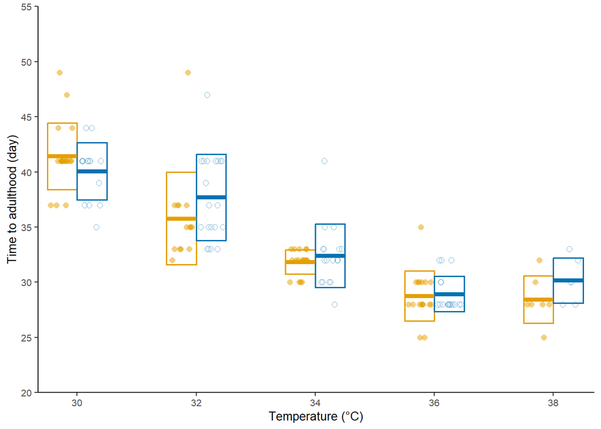

Figure 1: Time to reach adulthood for crickets reared at 5 temperatures. Boxes represent means (middle line) and standard deviations.

```r
ggplot(filter(f1_P, sex %in% c("Male", "Female")),
       aes(temperature, time_adult,
                 colour = sex, group = sex)) +
   geom_point(aes(shape = sex), position = position_jitterdodge(
               jitter.height = 0,
               jitter.width = 0.2,
               dodge.width = 0.5,
               seed = 1),
             size = 2,
             alpha = 0.5) +
  stat_summary(geom = "crossbar",
               fun = mean,
               fun.min = function(x) mean(x) - sd(x),
               fun.max = function(x) mean(x) + sd(x),
               width = 0.5,
               linewidth = 0.7,
               position = position_dodge()) +
  scale_colour_manual(values = sex_pal[2:3]) +
  scale_shape_manual(values = c(16, 1)) +
  scale_y_continuous(name = "Time to adulthood (day)",
                     breaks = seq(0, 55, 5),
                     expand = expansion(mult = c(0, 0)),
                     limits = c(20, 55)) +
  scale_x_discrete(name = "Temperature (°C)",
                   expand = expansion(mult = c(0, 0))) +
  theme(legend.position = "none")
```

```r
anova(lm(as.numeric(time_adult) ~ temperature * sex, f1_P)) %>% kable()
```

Table 6: ANOVA table for the effect of temperature and sex on the time to adulthood.

|  | Df | Sum Sq | Mean Sq | F value | Pr(>F) |
| --- | --- | --- | --- | --- | --- |
| temperature | 4 | 3186.981607 | 796.745402 | 101.6546479 | 0.0000000 |
| sex | 1 | 7.415188 | 7.415188 | 0.9460842 | 0.3323956 |
| temperature:sex | 4 | 51.089217 | 12.772304 | 1.6295847 | 0.1701399 |
| Residuals | 140 | 1097.287321 | 7.837767 | NA | NA |

# 7 Fecundity

## 7.1 Individuals

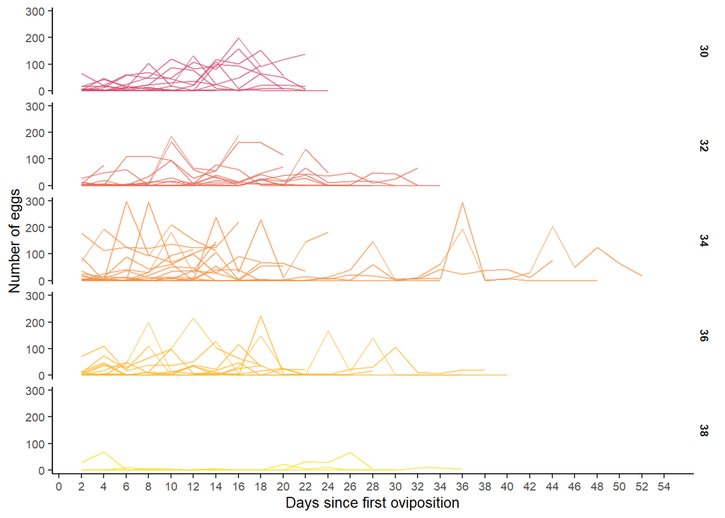

Figure 2: Time series of fecundity under common garden conditions for each mating pair (lines) reared at different temperatures (colours).

```r
f1_Eggs %>%
ggplot(aes(egg_day, eggs, group = pair, colour = temperature)) +
  geom_line(alpha = 0.7) +
  scale_colour_manual(values = temperature_pal) +
  facet_grid(temperature~.) +
  theme(legend.position = "none") +
  labs(x = "Days since first oviposition",
       y = "Number of eggs") +
  scale_x_continuous(breaks = seq(0, 54, 2))
```

## 7.2 Conservative measure of batches

Consider only batches of more than 5 eggs and the first 7 instances. This measure is not used in the study, which uses all batches of eggs until the end conditions are met.

```r
filtered_eggs <- f1_Eggs %>%
  group_by(pair) %>%
  filter(eggs >= 5) %>%
  # Keep only the first 14 days
  slice_head(n = 7)
```

```r
lm(eggs ~ egg_day + temperature, filtered_eggs) %>%
  anova() %>%
  kable()
```

Table 7: ANOVA table for the effect of temperature and time on fecundity.

|  | Df | Sum Sq | Mean Sq | F value | Pr(>F) |
| --- | --- | --- | --- | --- | --- |
| egg_day | 1 | 5175.145 | 5175.145 | 1.704227 | 0.1927364 |
| temperature | 4 | 41292.234 | 10323.059 | 3.399485 | 0.0097165 |
| Residuals | 300 | 910995.980 | 3036.653 | NA | NA |

## 7.3 By temperature

Overall there is no effect of temperature after considering parent size (as a ratio).

Censor data set to date when maximum 7 batches of more than 5 eggs was laid for each pair but keep all individuals and eggs regardless of number.

```r
# Censor time series
temp_eggs_all <- filtered_eggs %>%
  slice_max(day) %>%
  select(pair, day) %>%
  rename(end_date = day) %>%
  # Get the max date of 7 batches
  left_join(f1_Eggs, ., by = "pair") %>%
  mutate(end_date = ifelse(is.na(end_date), 54, end_date)) %>%
  mutate(flag = ifelse(day <=end_date, 1, 0)) %>%
  filter(flag == 1)

# does not include failed pairs
temp_eggs1 <- filter(temp_eggs_all, !is.na(egg_day))
# setdiff(temp_eggs_all$pair, temp_eggs1$pair)

# remove NA rows in failed pairs
temp_eggs_failed <- filter(temp_eggs_all, pair %in% failed) %>%
  filter(!is.na(eggs))

temp_eggs <- bind_rows(temp_eggs1, temp_eggs_failed) %>%
  # remove NA in poor performing pairs (dead)
  drop_na(eggs)
```

Number of distinct pairs and summary statistics of the number of eggs:

```r
n_distinct(temp_eggs$pair)
```

```
[1] 67
```

```r
summary(temp_eggs$eggs)
```

```
   Min. 1st Qu.  Median    Mean 3rd Qu.    Max.
    0.0     0.0     6.0    28.2    34.0   297.0
```

```r
# Get fecundity of each replicate pair
mean_fecundity <- temp_eggs %>%
  group_by(temperature, pair) %>%
  summarise(fecundity_pair = mean(eggs, na.rm = TRUE),
            med_eggs = median(eggs, na.rm = TRUE),
            sd_eggs = sd(eggs, na.rm = TRUE),
            n_batch = n(),
            total_eggs = sum(eggs, na.rm = TRUE)) %>%
  mutate(sd_eggs = ifelse(is.na(sd_eggs), 0, sd_eggs)) %>%
  mutate(se_eggs = sd_eggs/sqrt(n_batch)) %>%
  ungroup()
```

summary statistics of the total number and median of eggs per pair:

```r
summary(mean_fecundity$total_eggs) # total number
```

```
   Min. 1st Qu.  Median    Mean 3rd Qu.    Max.
    0.0    24.5   145.0   240.8   404.5   960.0
```

```r
summary(mean_fecundity$med_eggs) # median number
```

```
   Min. 1st Qu.  Median    Mean 3rd Qu.    Max.
   0.00    2.00    9.00   21.76   31.00  125.00
```

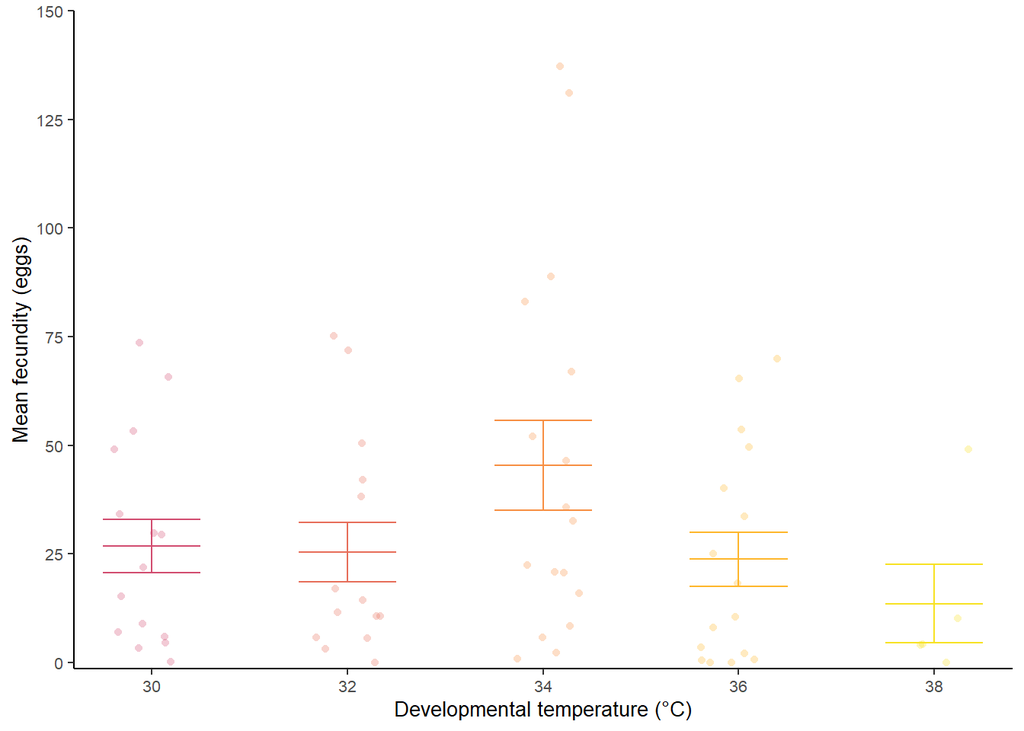

Figure 3: Mean fecundity of mating pairs under common garden conditions reared at 5 different temperatures.

```r
p_fecundity <- ggplot() +
  stat_summary(data = mean_fecundity,
               aes(temperature, fecundity_pair, colour = temperature),
               fun.data = mean_se, geom = "errorbar", width = 0.5) +
  stat_summary(data = mean_fecundity,
               aes(temperature, fecundity_pair, colour = temperature),
               geom = "crossbar",
  fun = mean,
  width = 0.5,
  fatten = 1) +
  geom_point(data = mean_fecundity,
             aes(temperature, fecundity_pair, colour = temperature),
             alpha = 0.3,
             position = position_jitter(
    height = 0,
    width = 0.2),
    size = 1.5,
    shape = 16) +
  scale_colour_manual("Temperature", values = temperature_pal) +
  scale_y_continuous(name = "Mean fecundity (eggs)",
                     breaks = seq(0, 150, 25),
                     expand = expansion(mult = c(0.01, 0)),
                     limits = c(0, 150)) +
  scale_x_discrete(name = "Developmental temperature (°C)",
                   expand = expansion(mult = c(0.1, 0.1))) +
  theme(legend.position = "none")

p_fecundity
```

Fit a model with pair as a random variable. Use Maximum Likelihood to compare models.

```r
mod_temp <- lme(fecundity_pair ~ temperature, rand =  ~1|pair, mean_fecundity, method = "ML")
summary(mod_temp)
```

```
Linear mixed-effects model fit by maximum likelihood
  Data: mean_fecundity
      AIC      BIC   logLik
  655.756 671.1889 -320.878

Random effects:
 Formula: ~1 | pair
        (Intercept) Residual
StdDev:    27.23485 10.21307

Fixed effects:  fecundity_pair ~ temperature
                   Value Std.Error DF   t-value p-value
(Intercept)    26.801587  7.807147 62  3.432955  0.0011
temperature32  -1.346998 11.236404 62 -0.119878  0.9050
temperature34  18.554645 10.711318 62  1.732247  0.0882
temperature36  -3.006200 10.867089 62 -0.276633  0.7830
temperature38 -13.308375 15.614295 62 -0.852320  0.3973
 Correlation:
              (Intr) tmpr32 tmpr34 tmpr36
temperature32 -0.695
temperature34 -0.729  0.506
temperature36 -0.718  0.499  0.524
temperature38 -0.500  0.347  0.364  0.359

Standardized Within-Group Residuals:
       Min         Q1        Med         Q3        Max
-0.5381315 -0.2655560 -0.1163933  0.2305015  1.1080077

Number of Observations: 67
Number of Groups: 67
```

```r
anova(mod_temp)
```

```
            numDF denDF  F-value p-value
(Intercept)     1    62 63.84722  <.0001
temperature     4    62  1.75391  0.1496
```

```r
# Test random effect against only fixed effect model (Analysis of Deviance)
anova.lme(mod_temp, lm(fecundity_pair ~ temperature, mean_fecundity))
```

```
                                                 Model df     AIC      BIC
mod_temp                                             1  7 655.756 671.1889
lm(fecundity_pair ~ temperature, mean_fecundity)     2  6 653.756 666.9842
                                                   logLik   Test L.Ratio
mod_temp                                         -320.878
lm(fecundity_pair ~ temperature, mean_fecundity) -320.878 1 vs 2       0
                                                 p-value
mod_temp
lm(fecundity_pair ~ temperature, mean_fecundity)       1
```

## 7.4 Total fecundity

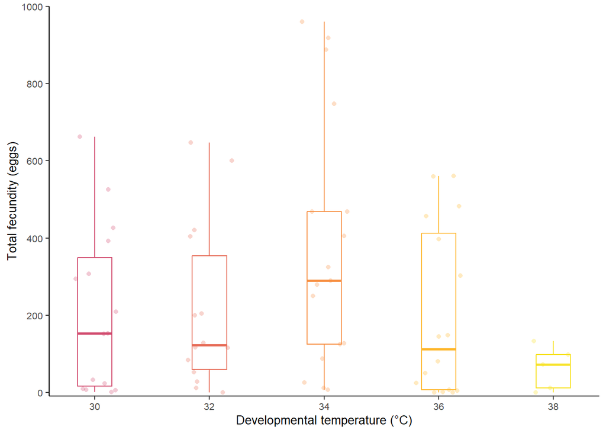

Figure 4: Total fecundity of mating pairs under common garden conditions reared at 5 different temperatures.

```r
p_totaleggs <- temp_eggs %>%
  group_by(temperature, pair) %>%
  summarise(total_eggs = sum(eggs),
            n = n()) %>%
  ggplot(aes(temperature, total_eggs, colour = temperature)) +
  geom_boxplot(width = 0.3, fill = NA) +
  geom_point(alpha = 0.3,
             position = position_jitter(
               height = 0,
               width = 0.2),
             size = 1.5,
             shape = 16) +
  scale_colour_manual(values = temperature_pal) +
  scale_y_continuous(name = "Total fecundity (eggs)",
                     breaks = seq(0, 1000, 200),
                     expand = expansion(mult = c(0.01, 0)),
                     limits = c(0, 1000)) +
  scale_x_discrete(name = "Developmental temperature (°C)",
                   expand = expansion(mult = c(0.1, 0.1))) +
  theme(legend.position = "none")

p_totaleggs
```

## 7.5 Parent size

```r
mass_fecundity <- f1_P %>%
  drop_na(adult_mass, pair) %>%
  select(sex, pair, temperature, adult_mass) %>%
  pivot_wider(names_from = sex, values_from = adult_mass) %>%
  left_join(mean_fecundity, ., by = c("pair", "temperature")) %>%
  mutate(adult_ratio = Female / Male)

# adult ratio
lm(fecundity_pair ~ adult_ratio + temperature, mass_fecundity) %>%
  summary()
```

```
Call:
lm(formula = fecundity_pair ~ adult_ratio + temperature, data = mass_fecundity)

Residuals:
    Min      1Q  Median      3Q     Max
-43.974 -20.285  -7.278  18.770  85.919

Coefficients:
               Estimate Std. Error t value Pr(>|t|)
(Intercept)    -0.06923   15.30854  -0.005   0.9964
adult_ratio    20.23346    9.99800   2.024   0.0474 *
temperature32  -1.04518   10.96700  -0.095   0.9244
temperature34  14.33481   10.65947   1.345   0.1837
temperature36  -5.60892   10.68325  -0.525   0.6015
temperature38 -20.26240   15.62113  -1.297   0.1995
---
Signif. codes:  0 '***' 0.001 '**' 0.01 '*' 0.05 '.' 0.1 ' ' 1

Residual standard error: 29.51 on 61 degrees of freedom
Multiple R-squared:  0.1582,    Adjusted R-squared:  0.08917
F-statistic: 2.292 on 5 and 61 DF,  p-value: 0.05645
```

Female mass only:

```r
summary(lm(fecundity_pair ~ Female + temperature, mass_fecundity))
```

```
Call:
lm(formula = fecundity_pair ~ Female + temperature, data = mass_fecundity)

Residuals:
    Min      1Q  Median      3Q     Max
-47.696 -20.174  -6.735  16.462  80.640

Coefficients:
               Estimate Std. Error t value Pr(>|t|)
(Intercept)   -14.95526   18.75289  -0.797    0.428
Female          0.16509    0.06793   2.430    0.018 *
temperature32  -3.52021   10.85343  -0.324    0.747
temperature34  10.32078   10.85337   0.951    0.345
temperature36 -13.94062   11.38745  -1.224    0.226
temperature38 -23.10997   15.56247  -1.485    0.143
---
Signif. codes:  0 '***' 0.001 '**' 0.01 '*' 0.05 '.' 0.1 ' ' 1

Residual standard error: 29.11 on 61 degrees of freedom
Multiple R-squared:  0.181, Adjusted R-squared:  0.1138
F-statistic: 2.696 on 5 and 61 DF,  p-value: 0.0289
```

Male mass only:

```r
# Male only
summary(lm(fecundity_pair ~ Male + temperature, mass_fecundity))
```

```
Call:
lm(formula = fecundity_pair ~ Male + temperature, data = mass_fecundity)

Residuals:
    Min      1Q  Median      3Q     Max
-43.983 -21.909  -9.812  19.031  91.336

Coefficients:
               Estimate Std. Error t value Pr(>|t|)
(Intercept)    28.97441   23.83092   1.216   0.2287
Male           -0.01089    0.11279  -0.097   0.9234
temperature32  -1.26929   11.35580  -0.112   0.9114
temperature34  18.57665   10.80033   1.720   0.0905 .
temperature36  -2.73484   11.30941  -0.242   0.8097
temperature38 -13.42887   15.78991  -0.850   0.3984
---
Signif. codes:  0 '***' 0.001 '**' 0.01 '*' 0.05 '.' 0.1 ' ' 1

Residual standard error: 30.48 on 61 degrees of freedom
Multiple R-squared:  0.1018,    Adjusted R-squared:  0.02817
F-statistic: 1.383 on 5 and 61 DF,  p-value: 0.2434
```

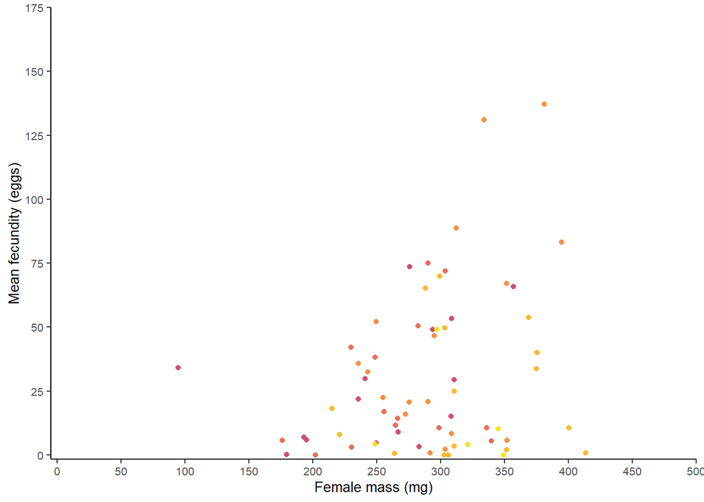

Figure 5: Mean fecundity of mating pairs under common garden conditions reared at 5 different temperatures compared to parental female mass.

```r
ggplot() +
  geom_point(data = mass_fecundity, aes(Female, fecundity_pair, colour = temperature)) +
  scale_colour_manual("Temperature (°C)", values = temperature_pal) +
  scale_y_continuous(name = "Mean fecundity (eggs)",
                     breaks = seq(0, 175, 25),
                     expand = expansion(mult = c(0.01, 0)),
                     limits = c(0, 175)) +
  scale_x_continuous(name = "Female mass (mg)",
                     breaks = seq(0, 500, 50),
                     expand = expansion(mult = c(0.01, 0)),
                     limits = c(0, 500)) +
  theme(legend.position = "none")
```

# 8 Time to first oviposition

Crickets reared at 38 °C have a delay in when they will start laying their first egg.

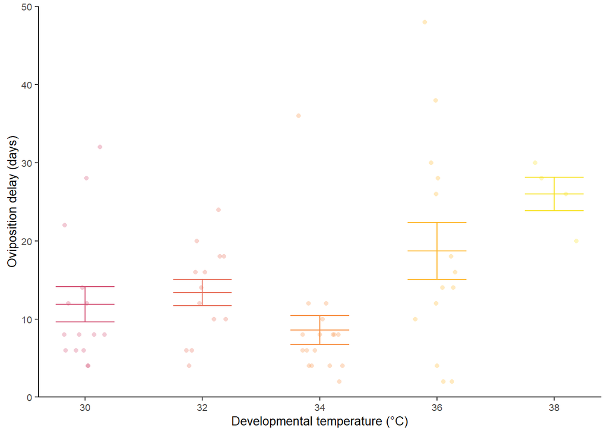

Figure 6: Time to lay the first batch of egg for crickets reared at 5 temperatures.

```r
egg_delay <- f1_Eggs %>%
  mutate(egg_lag = as.numeric(date_paired - first_egg)) %>%
  drop_na(egg_lag) %>%
  distinct(pair, temperature, egg_lag) %>%
  mutate(egg_lag = -egg_lag)

p_egg_delay <- ggplot(egg_delay, aes(temperature, egg_lag, colour = temperature)) +
  stat_summary(fun.data = mean_se, geom = "errorbar", width = 0.5) +
  stat_summary(geom = "crossbar",
               fun = mean,
               width = 0.5,
               fatten = 1) +
  geom_point(alpha = 0.3,
             position = position_jitter(
    height = 0,
    width = 0.2),
    size = 1.5,
    shape = 16) +
  scale_y_continuous(name = "Oviposition delay (days)", limits = c(0, 50),
                     expand = expansion(mult = c(0, 0))) +
  scale_x_discrete(name = "Developmental temperature (°C)",
                   expand = expansion(mult = c(0.1, 0.1))) +
  scale_colour_manual(values = temperature_pal) +
  theme(legend.position = "none")

p_egg_delay
```

```r
anova(lm(egg_lag ~ temperature, egg_delay)) %>% kable
```

Table 8: ANOVA table for the effect of temperature on the time to first oviposition.

|  | Df | Sum Sq | Mean Sq | F value | Pr(>F) |
| --- | --- | --- | --- | --- | --- |
| temperature | 4 | 1453.072 | 363.26802 | 4.280875 | 0.0042006 |
| Residuals | 58 | 4921.785 | 84.85836 | NA | NA |

```r
# Estimated marginal means with Tukey correction
emmeans(lm(egg_lag ~ temperature, egg_delay), ~temperature) %>% pairs(adjust = "tukey") %>%
  tidy() %>%
  filter(adj.p.value <= 0.05) %>%
  kable()
```

Table 9: Tukey’s Honest Significant Differences for the ANOVA. Non-significant contrast pairs are omitted.

| term | contrast | null.value | estimate | std.error | df | statistic | adj.p.value |
| --- | --- | --- | --- | --- | --- | --- | --- |
| temperature | temperature34 - temperature36 | 0 | -10.12605 | 3.324602 | 58 | -3.045793 | 0.0276883 |
| temperature | temperature34 - temperature38 | 0 | -17.41176 | 5.119205 | 58 | -3.401264 | 0.0103193 |

Fit a model with pair as a random variable. Use Maximum Likelihood to compare models.

```r
mod_delay <- lme(egg_lag ~ temperature, rand =  ~1|pair, egg_delay, method = "ML")
summary(mod_delay)
```

```
Linear mixed-effects model fit by maximum likelihood
  Data: egg_delay
       AIC      BIC    logLik
  467.3586 482.3606 -226.6793

Random effects:
 Formula: ~1 | pair
        (Intercept) Residual
StdDev:    8.275983 3.103494

Fixed effects:  egg_lag ~ temperature
                  Value Std.Error DF   t-value p-value
(Intercept)   11.866667  2.378492 58  4.989156  0.0000
temperature32  1.517949  3.490672 58  0.434859  0.6653
temperature34 -3.278431  3.263264 58 -1.004648  0.3192
temperature36  6.847619  3.423235 58  2.000336  0.0502
temperature38 14.133333  5.183803 58  2.726441  0.0085
 Correlation:
              (Intr) tmpr32 tmpr34 tmpr36
temperature32 -0.681
temperature34 -0.729  0.497
temperature36 -0.695  0.473  0.506
temperature38 -0.459  0.313  0.334  0.319

Standardized Within-Group Residuals:
        Min          Q1         Med          Q3         Max
-0.66398245 -0.18727710 -0.05500446  0.11971560  1.16338805

Number of Observations: 63
Number of Groups: 63
```

```r
anova(mod_delay)
```

```
            numDF denDF   F-value p-value
(Intercept)     1    58 139.63436  <.0001
temperature     4    58   4.28087  0.0042
```

```r
# Test random effect against only fixed effect model (Analysis of Deviance)
anova.lme(mod_delay, lm(egg_lag ~ temperature, egg_delay))
```

```
                                     Model df      AIC      BIC    logLik
mod_delay                                1  7 467.3586 482.3606 -226.6793
lm(egg_lag ~ temperature, egg_delay)     2  6 465.3586 478.2174 -226.6793
                                       Test               L.Ratio p-value
mod_delay
lm(egg_lag ~ temperature, egg_delay) 1 vs 2 0.0000000000001136868       1
```

# 9 Adult mass

Temperature dependent differences in sex.

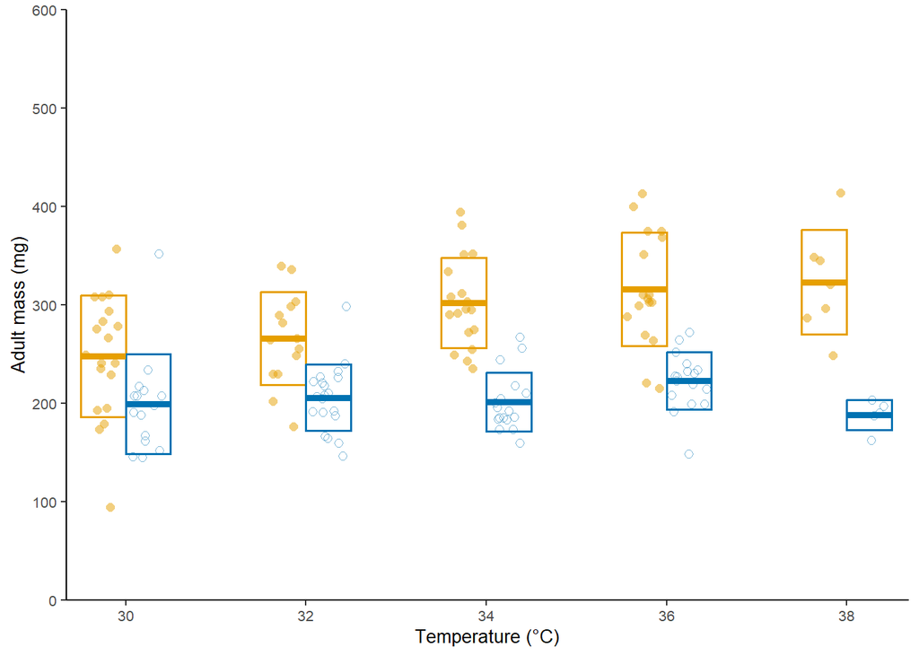

Figure 7: Adult mass for crickets reared at 5 temperatures. Boxes represent means (middle line) and standard deviations.

```r
ggplot(filter(f1_P, sex %in% c("Male", "Female")),
       aes(temperature, adult_mass,
                 colour = sex, group = sex)) +
   geom_point(aes(shape = sex), position = position_jitterdodge(
               jitter.height = 0,
               jitter.width = 0.2,
               dodge.width = 0.5,
               seed = 1),
             size = 2,
             alpha = 0.5) +
  stat_summary(geom = "crossbar",
               fun = mean,
               fun.min = function(x) mean(x) - sd(x),
               fun.max = function(x) mean(x) + sd(x),
               width = 0.5,
               linewidth = 0.7,
               position = position_dodge()) +
  scale_colour_manual(values = sex_pal[2:3]) +
  scale_shape_manual(values = c(16, 1)) +
  scale_y_continuous(name = "Adult mass (mg)",
                     breaks = seq(0, 600, 100),
                     expand = expansion(mult = c(0, 0)),
                     limits = c(0, 600)) +
  scale_x_discrete(name = "Temperature (°C)",
                   expand = expansion(mult = c(0, 0))) +
  theme(legend.position = "none")
```

```r
anova(lm(adult_mass ~ temperature * sex, filter(f1_P, sex %in% c("Male", "Female")))) %>%
  kable()
```

Table 10: ANOVA table for the effect of temperature and sex on adult mass.

|  | Df | Sum Sq | Mean Sq | F value | Pr(>F) |
| --- | --- | --- | --- | --- | --- |
| temperature | 4 | 46539.83 | 11634.957 | 5.581474 | 0.0003390 |
| sex | 1 | 240390.85 | 240390.848 | 115.319329 | 0.0000000 |
| temperature:sex | 4 | 25534.15 | 6383.537 | 3.062285 | 0.0187193 |
| Residuals | 139 | 289754.79 | 2084.567 | NA | NA |

## 9.1 Relationships with female mass

Egg delay:

- No effect of development time
- No effect of female mass

Mean fecundity:

```r
pair_fecundity <- f1_Eggs %>%
  group_by(pair, temperature) %>%
  summarise(mean_egg = mean(eggs, na.rm = TRUE),
            sd_egg = sd(eggs, na.rm = TRUE),
            n_eggs = n()) %>%
  mutate(se_eggs = sd_egg/sqrt(n_eggs))

pair_fecundity <- left_join(pair_fecundity, egg_delay, by = c("temperature", "pair"))

pair_fecundity <- f1_P %>%
  filter(sex == "Female") %>%
  drop_na(pair) %>%
  select(temperature, pair, adult_mass, time_adult) %>%
  left_join(pair_fecundity, ., by = c("temperature", "pair"))
```

The relationship between oviposition delay and fecundity for each mating pair:

```r
summary(lm(mean_egg ~ egg_lag, pair_fecundity))
```

```
Call:
lm(formula = mean_egg ~ egg_lag, data = pair_fecundity)

Residuals:
    Min      1Q  Median      3Q     Max
-35.108 -14.690  -3.934  10.082  87.824

Coefficients:
            Estimate Std. Error t value         Pr(>|t|)
(Intercept)   41.332      4.710   8.774 0.00000000000207 ***
egg_lag       -1.411      0.277  -5.095 0.00000361183165 ***
---
Signif. codes:  0 '***' 0.001 '**' 0.01 '*' 0.05 '.' 0.1 ' ' 1

Residual standard error: 22.11 on 61 degrees of freedom
  (4 observations deleted due to missingness)
Multiple R-squared:  0.2986,    Adjusted R-squared:  0.2871
F-statistic: 25.96 on 1 and 61 DF,  p-value: 0.000003612
```

# 10 Eggs

## 10.1 Egg development time

```r
pair_devtime <- f1_f1 %>%
  filter(dev_time < 17) %>% # one outlier; could be missed hatch
  group_by(pair, temperature) %>%
  summarise(pair_devtime = mean(dev_time, na.rm = TRUE),
            sd_devtime = sd(dev_time, na.rm = TRUE),
            n_devtime = n()) %>%
  mutate(sd_devtime = ifelse(is.na(sd_devtime), 0, sd_devtime),
         pair_devtime = ifelse(is.na(pair_devtime), 0, pair_devtime)) %>%
  filter(pair_devtime != 0)

mean_devtime <- pair_devtime %>%
  group_by(temperature) %>%
  summarise(mean_devtime = mean(pair_devtime, na.rm = TRUE),
            sd = sd(pair_devtime, na.rm = TRUE),
            n_devtime = n()) %>%
  mutate(sd = ifelse(is.na(sd), 0, sd)) %>%
  mutate(se_devtime = sd/sqrt(n_devtime),
         CV = (sd / mean_devtime) * 100)
```

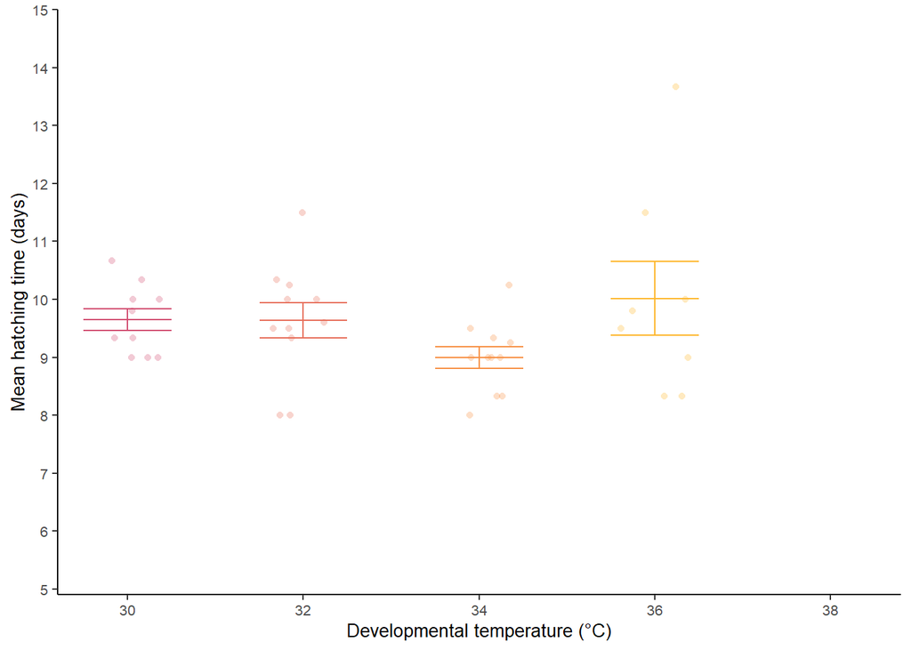

Figure 8: Mean time to hatch for eggs under common garden conditions from parents reared at 5 different temperatures until adulthood.

```r
p_devtime <- ggplot(pair_devtime, aes(temperature, pair_devtime, colour = temperature)) +
  stat_summary(fun.data = mean_se, geom = "errorbar", width = 0.5) +
  stat_summary(geom = "crossbar",
               fun = mean,
               width = 0.5,
               fatten = 1) +
  geom_point(alpha = 0.3,
             position = position_jitter(
    height = 0,
    width = 0.2),
    size = 1.5,
    shape = 16) +
  scale_colour_manual("Temperature", values = temperature_pal) +
  scale_y_continuous(name = "Mean hatching time (days)",
                     breaks = seq(0, 20, 1),
                     expand = expansion(mult = c(0.01, 0)),
                     limits = c(5, 15)) +
  scale_x_discrete(name = "Developmental temperature (°C)",
                   expand = expansion(mult = c(0.1, 0.1)),
                   limits = as.character(seq(30, 38, 2))) +
  theme(legend.position = "none")

p_devtime
```

```r
anova(lm(pair_devtime ~ temperature, pair_devtime)) %>% kable()
```

Table 11: ANOVA table for the effect of parental developmental temperature on egg hatching time.

|  | Df | Sum Sq | Mean Sq | F value | Pr(>F) |
| --- | --- | --- | --- | --- | --- |
| temperature | 3 | 5.244443 | 1.748147 | 1.58385 | 0.2101826 |
| Residuals | 36 | 39.734384 | 1.103733 | NA | NA |

```r
kable(mean_devtime, digits = 3)
```

Table 12: Summary statistics for egg hatching time.

| temperature | mean_devtime | sd | n_devtime | se_devtime | CV |
| --- | --- | --- | --- | --- | --- |
| 30 | 9.647 | 0.600 | 10 | 0.190 | 6.216 |
| 32 | 9.638 | 1.004 | 11 | 0.303 | 10.420 |
| 34 | 9.000 | 0.622 | 11 | 0.188 | 6.917 |
| 36 | 10.017 | 1.794 | 8 | 0.634 | 17.914 |

Fit a model with pair as a random variable. Use Maximum Likelihood to compare models.

```r
mod_devtime <- lme(dev_time ~ temperature, rand =  ~1|pair, drop_na(f1_f1, dev_time), method = "ML")
summary(mod_devtime)
```

```
Linear mixed-effects model fit by maximum likelihood
  Data: drop_na(f1_f1, dev_time)
       AIC     BIC  logLik
  689.5601 707.036 -338.78

Random effects:
 Formula: ~1 | pair
         (Intercept) Residual
StdDev: 0.0004799294 2.921483

Fixed effects:  dev_time ~ temperature
                  Value Std.Error DF   t-value p-value
(Intercept)    9.552632 0.4810542 96 19.857703  0.0000
temperature32  1.478618 0.7114888 36  2.078203  0.0449
temperature34 -0.266917 0.6639179 36 -0.402034  0.6900
temperature36  0.530702 0.7731865 36  0.686383  0.4969
 Correlation:
              (Intr) tmpr32 tmpr34
temperature32 -0.676
temperature34 -0.725  0.490
temperature36 -0.622  0.421  0.451

Standardized Within-Group Residuals:
       Min         Q1        Med         Q3        Max
-1.2160372 -0.4400896 -0.1891613  0.1759715  9.2311861

Number of Observations: 136
Number of Groups: 40
```

```r
anova(mod_devtime)
```

```
            numDF denDF   F-value p-value
(Intercept)     1    96 1519.3900  <.0001
temperature     3    36    2.3567   0.088
```

```r
# Test random effect against only fixed effect model (Analysis of Deviance)
anova.lme(mod_devtime, lm(dev_time ~ temperature, drop_na(f1_f1, dev_time)))
```

```
                                                     Model df      AIC      BIC
mod_devtime                                              1  6 689.5601 707.0360
lm(dev_time ~ temperature, drop_na(f1_f1, dev_time))     2  5 687.5601 702.1234
                                                      logLik   Test
mod_devtime                                          -338.78
lm(dev_time ~ temperature, drop_na(f1_f1, dev_time)) -338.78 1 vs 2
                                                              L.Ratio p-value
mod_devtime
lm(dev_time ~ temperature, drop_na(f1_f1, dev_time)) 0.00000008792517  0.9998
```

## 10.2 Hatching probability

```r
f1_f1 %>%
  group_by(pair, temperature) %>%
  summarise(success = (sum(hatching_success)/n()) * 100,
            batches = n()) %>%
  group_by(temperature) %>%
  summarise(mean_success = mean(success)) %>%
  kable()
```

Table 13: Mean hatching probability for eggs under common garden conditions from parent reared at 5 different temperatures.

| temperature | mean_success |
| --- | --- |
| 30 | 81.21212 |
| 32 | 81.51515 |
| 34 | 85.13889 |
| 36 | 75.00000 |
| 38 | 0.00000 |

## 10.3 Hatching success

Overall mean hatching success is very low (22.3%) but two batches had 100%! Summary statistics of hatching success:

```r
hatching_success <- f1_Eggs %>%
  select(pair, date, eggs, temperature) %>%
  left_join(f1_f1, ., by = c("pair" = "pair",
                            "date_laid" = "date",
                            "temperature" = "temperature")) %>%
  mutate(success = (no_hatchlings/eggs) * 100)

summary(hatching_success$success)
```

```
   Min. 1st Qu.  Median    Mean 3rd Qu.    Max.    NA's
  0.000   2.303  16.441  22.347  33.733 100.000       1
```

```r
sum_succ <- hatching_success %>%
group_by(pair, temperature) %>%
  summarise(mean_success = ifelse(is.nan(mean(success)), 0, mean(success))) %>%
  group_by(temperature) %>%
   summarise(n_pair = n(),
             mean = mean(mean_success),
             sd = sd(mean_success),
             min = min(mean_success),
             max = max(mean_success))

kable(sum_succ, digits = 2)
```

Table 14: Summary statistics for egg hatching success.

| temperature | n_pair | mean | sd | min | max |
| --- | --- | --- | --- | --- | --- |
| 30 | 11 | 17.99 | 9.90 | 0.0 | 35.34 |
| 32 | 11 | 26.35 | 20.43 | 2.5 | 71.43 |
| 34 | 12 | 31.88 | 18.95 | 0.0 | 61.84 |
| 36 | 10 | 21.91 | 19.09 | 0.0 | 54.43 |
| 38 | 3 | 0.00 | 0.00 | 0.0 | 0.00 |

# 11 Figures

```r
# figure 3 - mass
fecundity_plot <- plot_grid(
  p_egg_delay,
  p_fecundity,
  p_totaleggs,
  p_devtime,
  ncol = 2,
  nrow = 2,
  labels = "AUTO",
  align = "v"
  )

ggsave("F1/output/fecundity_plot.png", plot = fecundity_plot,
       dpi = 300,
       height = 150,
       width = 170,
       units = "mm")
```